# Bryant Analysis

Ellen Herschel, Colin McDaniel, Sherry Zhang

11/8/2021

# Read in Data

```r
# Import R data
alldata <- read.csv("~/Desktop/Coursework/Fall 2021/Multilevel Modeling/psyc575/Music_Sports_Empathy/Music_Sports_Empathy/Full Data Sets/sport_music_dat_mlm_long2.csv")

#alldata <- read.csv("sport_music_dat_mlm_long2.csv")

widedata<- read.csv("~/Desktop/Coursework/Fall 2021/Multilevel Modeling/psyc575/Music_Sports_Empathy/Music_Sports_Empathy/Full Data Sets/sport_music_dat_mlm_wide.csv")

#widedata<- read.csv("sport_music_dat_mlm_wide.csv")
```

#Factor, Get rid of NAs

```r
# Code Year and Group as factors
alldata$year <- factor(alldata$year)
alldata$group <- factor(alldata$group)

alldata$time<-as.integer(alldata$year)

# Remove NAs from data
alldata1<- drop_na(alldata, wasi_vci, group, bryant_percent, wasi_age)
```

# Mean-center variables

```r
# Mean-center Age
alldata1 <- alldata1 %>%
  group_by(id) %>%   # operate within individual
  mutate(age_pm = mean(wasi_age),   # create individual means (the same as `meanses`)
         age_pmc = wasi_age - age_pm) %>%   # cluster-mean centered
  ungroup()  # exit the "editing within groups" mode

alldata1 %>%
  select(id, wasi_age, age_pm, age_pmc)
```

| id | wasi_age | age_pm | age_pmc |
| --- | --- | --- | --- |
| M102 | 6.441096 | 9.165753 | -2.724657535 |
| M106 | 7.213699 | 8.690411 | -1.476712328 |
| M107 | 7.334247 | 9.258630 | -1.924383561 |
| M108 | 6.339726 | 8.992694 | -2.652968037 |
| M109 | 6.189041 | 8.153425 | -1.964383562 |
| M112 | 6.717808 | 8.091781 | -1.373972603 |
| M113 | 7.002740 | 8.903014 | -1.900273972 |
| S101 | 7.624658 | 9.688767 | -2.064109589 |
| S103 | 6.301370 | 9.006393 | -2.705022831 |
| S104 | 6.843836 | 8.927671 | -2.083835617 |

[output cut: 369 more lines]

```r
# Mean-center verbal ability
alldata1 <- alldata1 %>%
  group_by(id) %>%   # operate within individual
  mutate(verbal_pm = mean(wasi_vci),   # create individual means (the same as `meanses`)
         verbal_pmc = wasi_vci - verbal_pm) %>%   # cluster-mean centered
  ungroup()  # exit the "editing within groups" mode

alldata1 %>%
  select(id, wasi_vci, verbal_pm, verbal_pmc)
```

| id | wasi_vci | verbal_pm | verbal_pmc |
| --- | --- | --- | --- |
| M102 | 99 | 104.00000 | -5.0000000 |
| M106 | 98 | 96.00000 | 2.0000000 |
| M107 | 86 | 76.60000 | 9.4000000 |
| M108 | 102 | 110.33333 | -8.3333333 |
| M109 | 98 | 105.20000 | -7.2000000 |
| M112 | 105 | 105.50000 | -0.5000000 |
| M113 | 85 | 89.20000 | -4.2000000 |
| S101 | 77 | 80.80000 | -3.8000000 |
| S103 | 105 | 101.16667 | 3.8333333 |
| S104 | 102 | 97.20000 | 4.8000000 |

[output cut: 369 more lines]

```r
datasummary_skim(alldata1 %>%
                   select(bryant_percent, time, wasi_age, group, wasi_vci ))
```

|  | Unique (#) | Missing (%) | Mean | SD | Min | Median | Max |  |
| --- | --- | --- | --- | --- | --- | --- | --- | --- |
| bryant_percent | 45 | 0 | 0.6 | 0.1 | 0.1 | 0.6 | 0.9 |  |
| time | 6 | 0 | 3.1 | 1.6 | 1.0 | 3.0 | 6.0 |  |
| wasi_age | 352 | 0 | 9.1 | 2.0 | 5.7 | 9.0 | 14.1 |  |
| wasi_vci | 62 | 0 | 98.2 | 11.9 | 68.0 | 98.0 | 142.0 |  |

# Check for differences in baseline Age

```r
# Code Group as factor
widedata$group <- factor(widedata$group)

agebase<-aov(wasi_age_Y1~group, widedata)
summary(agebase)
```

```
##             Df Sum Sq Mean Sq F value  Pr(>F)
## group        2  2.757  1.3786    5.11 0.00815 **
## Residuals   80 21.582  0.2698
## ---
## Signif. codes:  0 '***' 0.001 '**' 0.01 '*' 0.05 '.' 0.1 ' ' 1
```

# Attrition Analysis

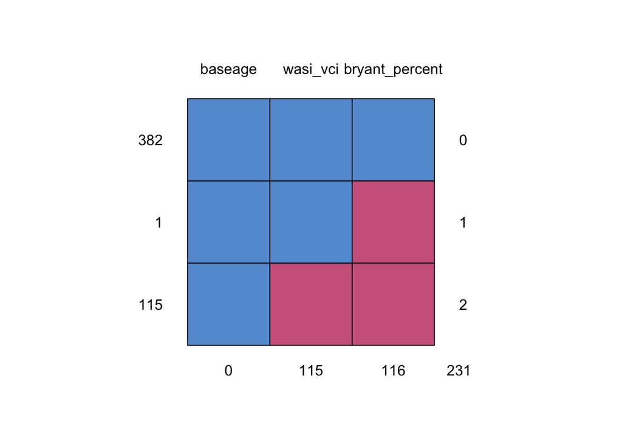

```
##     baseage wasi_vci bryant_percent
## 382       1        1              1   0
## 1         1        1              0   1
## 115       1        0              0   2
##           0      115            116 231
```

```r
# Replace incorrectly placed 0s with NA
alldata$bryant_percent[alldata$bryant_percent == 0] <- NA

# Examine missing data patterns
md.pattern(alldata[,c("bryant_percent", "baseage", "wasi_vci")])
```

```r
# Attrition analysis setup
alldata$miss_bryant_percent <- ifelse(is.na(alldata$bryant_percent), 1, 0)
alldata$miss_baseage <- ifelse(is.na(alldata$baseage), 1, 0)
alldata$miss_wasi_vci <- ifelse(is.na(alldata$wasi_vci), 1, 0)

# Test whether bryant_percent is missing completely at random
t.test(alldata$baseage[alldata$miss_bryant_percent==0], alldata$baseage[alldata$miss_bryant_percent==1], alternative = "two.sided", conf.level = .95, var.equal = TRUE)
```

```
##
##  Two Sample t-test
##
## data:  alldata$baseage[alldata$miss_bryant_percent == 0] and alldata$baseage[alldata$miss_bryant_percent == 1]
## t = 0.82869, df = 496, p-value = 0.4077
## alternative hypothesis: true difference in means is not equal to 0
## 95 percent confidence interval:
##  -0.06530549  0.16057836
## sample estimates:
## mean of x mean of y
##  6.820405  6.772768
```

```r
t.test(alldata$wasi_vci[alldata$miss_bryant_percent==0], alldata$wasi_vci[alldata$miss_bryant_percent==1], alternative = "two.sided", conf.level = .95, var.equal = TRUE)
```

```
##
##  Two Sample t-test
##
## data:  alldata$wasi_vci[alldata$miss_bryant_percent == 0] and alldata$wasi_vci[alldata$miss_bryant_percent == 1]
## t = 1.7758, df = 381, p-value = 0.07657
## alternative hypothesis: true difference in means is not equal to 0
## 95 percent confidence interval:
##  -2.27259 44.66002
## sample estimates:
## mean of x mean of y
##  98.19372  77.00000
```

```r
# Test whether wasi_vci is missing completely at random
# t.test(alldata$bryant_percent[alldata$miss_wasi_vci==0], alldata$bryant_percent[alldata$miss_wasi_vci==1], alternative = "two.sided", conf.level = .95, var.equal = TRUE) # Commented out because bryant_percent is NA at every point where wasi_vci is NA
t.test(alldata$baseage[alldata$miss_wasi_vci==0], alldata$baseage[alldata$miss_wasi_vci==1], alternative = "two.sided", conf.level = .95, var.equal = TRUE)
```

```
##
##  Two Sample t-test
##
## data:  alldata$baseage[alldata$miss_wasi_vci == 0] and alldata$baseage[alldata$miss_wasi_vci == 1]
## t = 0.80517, df = 496, p-value = 0.4211
## alternative hypothesis: true difference in means is not equal to 0
## 95 percent confidence interval:
##  -0.06686212  0.15971411
## sample estimates:
## mean of x mean of y
##  6.820029  6.773603
```

# Check assumptions

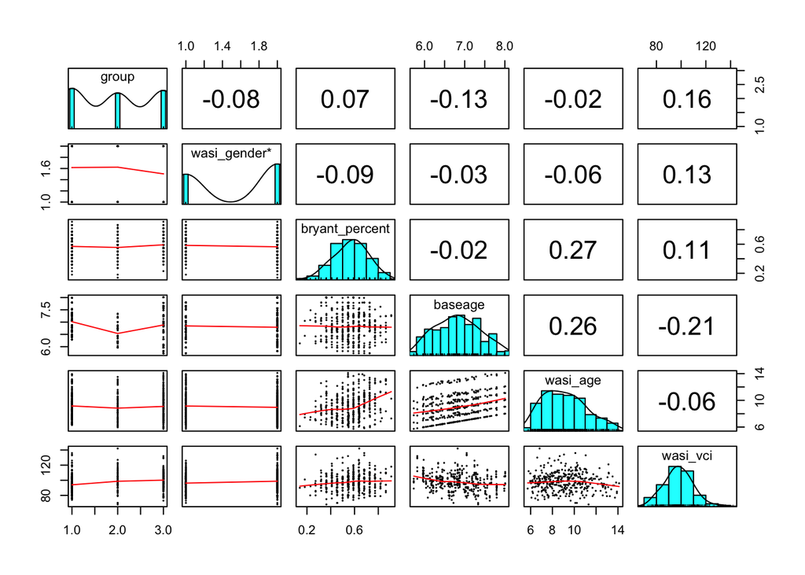

```r
alldata1 %>%
  # Select the variables to be used
  select(group, wasi_gender, bryant_percent, baseage, wasi_age, wasi_vci) %>%
  psych::pairs.panels(ellipses = FALSE, cex = 0.2, cex.cor = 1)
```

The data for bryant_percent, baseage, and wasi_vci (the continuous variables being included in the model) appear relatively normal.

# Write Down Model Equations

Lv-1:
$$\mathrm{empathybryant}_{ti} = \beta_{0i} + \beta_{1i}\mathrm{time}_{ti} + \beta_{2i}\mathrm{verbalpmc}_{ti} + e_{ti}$$
Lv-2:
$$\beta_{0i} = \gamma_{00} + \gamma_{01}\mathrm{baseage}_i + \gamma_{02}\mathrm{verbalpm_i} + \gamma_{03}\mathrm{group}_i+ u_{0i}$$
$$\beta_{1i} = \gamma_{10} + \gamma_{11}\mathrm{verbalpm}_i + \gamma_{12}\mathrm{group}_i + u_{1i}$$
$$\beta_{2i} = \gamma_{20} + \gamma_{21}\mathrm{baseage}_i + \gamma_{22}\mathrm{group}_i + u_{2i}$$

# Baseline Model

```r
#model with just base interaction of year and group, and no random slopes
m0 <- glmmTMB(bryant_percent ~ time + (1 | id),
    data = alldata1,
)

summary(m0)
```

```
##  Family: gaussian  ( identity )
## Formula:          bryant_percent ~ time + (1 | id)
## Data: alldata1
##
##      AIC      BIC   logLik deviance df.resid
##   -439.2   -423.4    223.6   -447.2      375
##
## Random effects:
##
## Conditional model:
##  Groups   Name        Variance Std.Dev.
##  id       (Intercept) 0.004112 0.06413
##  Residual             0.015186 0.12323
## Number of obs: 379, groups:  id, 83
##
## Dispersion estimate for gaussian family (sigma^2): 0.0152
##
## Conditional model:
##             Estimate Std. Error z value Pr(>|z|)
## (Intercept) 0.493450   0.015421    32.0  < 2e-16 ***
## time        0.024425   0.003942     6.2 5.77e-10 ***
## ---
## Signif. codes:  0 '***' 0.001 '**' 0.01 '*' 0.05 '.' 0.1 ' ' 1
```

# Add in and test covariates and random slopes

```r
#model

m1 <- glmmTMB(bryant_percent ~ time + group + (1 | id),
    data = alldata1,
)

summary(m1)
```

```
##  Family: gaussian  ( identity )
## Formula:          bryant_percent ~ time + group + (1 | id)
## Data: alldata1
##
##      AIC      BIC   logLik deviance df.resid
##   -437.7   -414.1    224.8   -449.7      373
##
## Random effects:
##
## Conditional model:
##  Groups   Name        Variance Std.Dev.
##  id       (Intercept) 0.003871 0.06222
##  Residual             0.015188 0.12324
## Number of obs: 379, groups:  id, 83
##
## Dispersion estimate for gaussian family (sigma^2): 0.0152
##
## Conditional model:
##              Estimate Std. Error z value Pr(>|z|)
## (Intercept)  0.487358   0.019982  24.390  < 2e-16 ***
## time         0.024348   0.003939   6.182 6.35e-10 ***
## groupMusic  -0.009137   0.023520  -0.388    0.698
## groupSport   0.027459   0.023139   1.187    0.235
## ---
## Signif. codes:  0 '***' 0.001 '**' 0.01 '*' 0.05 '.' 0.1 ' ' 1
```

```r
anova(m0, m1)
```

|  | Df | AIC | BIC | logLik | deviance | Chisq | Chi Df | Pr(>Chisq) |
| --- | --- | --- | --- | --- | --- | --- | --- | --- |
| m0 | 4 | -439.1519 | -423.4018 | 223.5760 | -447.1519 | NA | NA | NA |
| m1 | 6 | -437.6923 | -414.0671 | 224.8462 | -449.6923 | 2.540372 | 2 | 0.2807794 |

```r
#add interaction of year and group
m2 <- glmmTMB(bryant_percent ~ time*group + (1 | id),
    data = alldata1,
)
summary(m2)
```

```
##  Family: gaussian  ( identity )
## Formula:          bryant_percent ~ time * group + (1 | id)
## Data: alldata1
##
##      AIC      BIC   logLik deviance df.resid
##   -435.9   -404.4    225.9   -451.9      371
##
## Random effects:
##
## Conditional model:
##  Groups   Name        Variance Std.Dev.
##  id       (Intercept) 0.003799 0.06164
##  Residual             0.015125 0.12299
## Number of obs: 379, groups:  id, 83
##
## Dispersion estimate for gaussian family (sigma^2): 0.0151
##
## Conditional model:
##                  Estimate Std. Error z value Pr(>|z|)
## (Intercept)      0.467162   0.025648  18.214  < 2e-16 ***
## time             0.031049   0.006656   4.665 3.09e-06 ***
## groupMusic       0.034179   0.037532   0.911    0.362
## groupSport       0.047555   0.036807   1.292    0.196
## time:groupMusic -0.014366   0.009742  -1.475    0.140
## time:groupSport -0.006676   0.009439  -0.707    0.479
## ---
## Signif. codes:  0 '***' 0.001 '**' 0.01 '*' 0.05 '.' 0.1 ' ' 1
```

```r
anova(m1, m2) #not sig, but this is what we want to test)
```

|  | Df | AIC | BIC | logLik | deviance | Chisq | Chi Df | Pr(>Chisq) |
| --- | --- | --- | --- | --- | --- | --- | --- | --- |
| m1 | 6 | -437.6923 | -414.0671 | 224.8462 | -449.6923 | NA | NA | NA |
| m2 | 8 | -435.8641 | -404.3638 | 225.9320 | -451.8641 | 2.171749 | 2 | 0.3376064 |

```r
#add more covariates
#verbal (person mean-centered)
m3 <- glmmTMB(bryant_percent ~ time*group + verbal_pmc + (1 | id),
    data = alldata1,
)
summary(m3)
```

```
##  Family: gaussian  ( identity )
## Formula:          bryant_percent ~ time * group + verbal_pmc + (1 | id)
## Data: alldata1
##
##      AIC      BIC   logLik deviance df.resid
##   -434.4   -399.0    226.2   -452.4      370
##
## Random effects:
##
## Conditional model:
##  Groups   Name        Variance Std.Dev.
##  id       (Intercept) 0.003803 0.06167
##  Residual             0.015100 0.12288
## Number of obs: 379, groups:  id, 83
##
## Dispersion estimate for gaussian family (sigma^2): 0.0151
##
## Conditional model:
##                   Estimate Std. Error z value Pr(>|z|)
## (Intercept)      0.4667410  0.0256402  18.203  < 2e-16 ***
## time             0.0311885  0.0066534   4.688 2.76e-06 ***
## groupMusic       0.0355334  0.0375568   0.946    0.344
## groupSport       0.0468899  0.0367972   1.274    0.203
## verbal_pmc       0.0007471  0.0010237   0.730    0.466
## time:groupMusic -0.0148133  0.0097540  -1.519    0.129
## time:groupSport -0.0064608  0.0094360  -0.685    0.494
## ---
## Signif. codes:  0 '***' 0.001 '**' 0.01 '*' 0.05 '.' 0.1 ' ' 1
```

```r
anova(m2, m3)
```

|  | Df | AIC | BIC | logLik | deviance | Chisq | Chi Df | Pr(>Chisq) |
| --- | --- | --- | --- | --- | --- | --- | --- | --- |
| m2 | 8 | -435.8641 | -404.3638 | 225.9320 | -451.8641 | NA | NA | NA |
| m3 | 9 | -434.3963 | -398.9584 | 226.1981 | -452.3963 | 0.532198 | 1 | 0.4656842 |

```r
#is not sig

#verbal (person mean)
m4 <- glmmTMB(bryant_percent ~ time*group + verbal_pm + (1 | id),
    data = alldata1,
)
summary(m4)
```

```
##  Family: gaussian  ( identity )
## Formula:          bryant_percent ~ time * group + verbal_pm + (1 | id)
## Data: alldata1
##
##      AIC      BIC   logLik deviance df.resid
##   -436.8   -401.4    227.4   -454.8      370
##
## Random effects:
##
## Conditional model:
##  Groups   Name        Variance Std.Dev.
##  id       (Intercept) 0.003554 0.05961
##  Residual             0.015117 0.12295
## Number of obs: 379, groups:  id, 83
##
## Dispersion estimate for gaussian family (sigma^2): 0.0151
##
## Conditional model:
##                   Estimate Std. Error z value Pr(>|z|)
## (Intercept)      0.3133477  0.0925595   3.385 0.000711 ***
## time             0.0312395  0.0066492   4.698 2.62e-06 ***
## groupMusic       0.0309659  0.0373354   0.829 0.406880
## groupSport       0.0434036  0.0366399   1.185 0.236175
## verbal_pm        0.0016010  0.0009268   1.727 0.084083 .
## time:groupMusic -0.0149180  0.0097391  -1.532 0.125579
## time:groupSport -0.0074586  0.0094402  -0.790 0.429479
## ---
## Signif. codes:  0 '***' 0.001 '**' 0.01 '*' 0.05 '.' 0.1 ' ' 1
```

```r
anova(m2, m4)
```

|  | Df | AIC | BIC | logLik | deviance | Chisq | Chi Df | Pr(>Chisq) |
| --- | --- | --- | --- | --- | --- | --- | --- | --- |
| m2 | 8 | -435.8641 | -404.3638 | 225.9320 | -451.8641 | NA | NA | NA |
| m4 | 9 | -436.7997 | -401.3619 | 227.3999 | -454.7997 | 2.935679 | 1 | 0.08664221 |

```r
#is sig (p val divided by 2)

# age
m5 <- glmmTMB(bryant_percent ~ time*group + verbal_pm + baseage + (1 | id),
    data = alldata1,
)
summary(m5)
```

```
##  Family: gaussian  ( identity )
## Formula:
## bryant_percent ~ time * group + verbal_pm + baseage + (1 | id)
## Data: alldata1
##
##      AIC      BIC   logLik deviance df.resid
##   -434.9   -395.6    227.5   -454.9      369
##
## Random effects:
##
## Conditional model:
##  Groups   Name        Variance Std.Dev.
##  id       (Intercept) 0.003554 0.05961
##  Residual             0.015112 0.12293
## Number of obs: 379, groups:  id, 83
##
## Dispersion estimate for gaussian family (sigma^2): 0.0151
##
## Conditional model:
##                   Estimate Std. Error z value Pr(>|z|)
## (Intercept)      0.3685761  0.1783105   2.067   0.0387 *
## time             0.0312886  0.0066493   4.706 2.53e-06 ***
## groupMusic       0.0282247  0.0380938   0.741   0.4587
## groupSport       0.0428092  0.0366709   1.167   0.2431
## verbal_pm        0.0015185  0.0009542   1.591   0.1115
## baseage         -0.0067634  0.0186660  -0.362   0.7171
## time:groupMusic -0.0149785  0.0097388  -1.538   0.1240
## time:groupSport -0.0074998  0.0094392  -0.795   0.4269
## ---
## Signif. codes:  0 '***' 0.001 '**' 0.01 '*' 0.05 '.' 0.1 ' ' 1
```

```r
anova(m4, m5)
```

|  | Df | AIC | BIC | logLik | deviance | Chisq | Chi Df | Pr(>Chisq) |
| --- | --- | --- | --- | --- | --- | --- | --- | --- |
| m4 | 9 | -436.7997 | -401.3619 | 227.3999 | -454.7997 | NA | NA | NA |
| m5 | 10 | -434.9311 | -395.5558 | 227.4656 | -454.9311 | 0.1313794 | 1 | 0.7170061 |

```r
# not sig, dont include baseline age

#gender
m6 <- glmmTMB(bryant_percent ~ time*group + verbal_pm + wasi_gender + (1 | id),
    data = alldata1,
)
summary(m6)
```

```
##  Family: gaussian  ( identity )
## Formula:
## bryant_percent ~ time * group + verbal_pm + wasi_gender + (1 |      id)
## Data: alldata1
##
##      AIC      BIC   logLik deviance df.resid
##   -437.4   -398.0    228.7   -457.4      369
##
## Random effects:
##
## Conditional model:
##  Groups   Name        Variance Std.Dev.
##  id       (Intercept) 0.003377 0.05811
##  Residual             0.015094 0.12286
## Number of obs: 379, groups:  id, 83
##
## Dispersion estimate for gaussian family (sigma^2): 0.0151
##
## Conditional model:
##                   Estimate Std. Error z value Pr(>|z|)
## (Intercept)      0.3104807  0.0914036   3.397 0.000682 ***
## time             0.0311613  0.0066383   4.694 2.68e-06 ***
## groupMusic       0.0302787  0.0371324   0.815 0.414830
## groupSport       0.0411448  0.0364679   1.128 0.259216
## verbal_pm        0.0018285  0.0009253   1.976 0.048155 *
## wasi_genderm    -0.0306602  0.0190109  -1.613 0.106794
## time:groupMusic -0.0149328  0.0097229  -1.536 0.124579
## time:groupSport -0.0079246  0.0094303  -0.840 0.400723
## ---
## Signif. codes:  0 '***' 0.001 '**' 0.01 '*' 0.05 '.' 0.1 ' ' 1
```

```r
anova(m4, m6)
```

|  | Df | AIC | BIC | logLik | deviance | Chisq | Chi Df | Pr(>Chisq) |
| --- | --- | --- | --- | --- | --- | --- | --- | --- |
| m4 | 9 | -436.7997 | -401.3619 | 227.3999 | -454.7997 | NA | NA | NA |
| m6 | 10 | -437.3744 | -397.9990 | 228.6872 | -457.3744 | 2.574613 | 1 | 0.1085907 |

```r
#not sig, gender doesnt seem to improve the model


#test for random slopes

#time
m4.1 <- glmmTMB(bryant_percent ~ time*group + verbal_pm + (time | id),
    data = alldata1,
)
summary(m4.1)
```

```
##  Family: gaussian  ( identity )
## Formula:          bryant_percent ~ time * group + verbal_pm + (time | id)
## Data: alldata1
##
##      AIC      BIC   logLik deviance df.resid
##   -443.1   -399.8    232.5   -465.1      368
##
## Random effects:
##
## Conditional model:
##  Groups   Name        Variance  Std.Dev. Corr
##  id       (Intercept) 0.0110347 0.10505
##           time        0.0007596 0.02756  -0.81
##  Residual             0.0128076 0.11317
## Number of obs: 379, groups:  id, 83
##
## Dispersion estimate for gaussian family (sigma^2): 0.0128
##
## Conditional model:
##                   Estimate Std. Error z value Pr(>|z|)
## (Intercept)      0.3181365  0.0936341   3.398 0.000680 ***
## time             0.0287412  0.0083318   3.450 0.000561 ***
## groupMusic       0.0254036  0.0425363   0.597 0.550359
## groupSport       0.0384899  0.0417082   0.923 0.356091
## verbal_pm        0.0016083  0.0009271   1.735 0.082800 .
## time:groupMusic -0.0125937  0.0121535  -1.036 0.300099
## time:groupSport -0.0050540  0.0118329  -0.427 0.669299
## ---
## Signif. codes:  0 '***' 0.001 '**' 0.01 '*' 0.05 '.' 0.1 ' ' 1
```

```r
anova(m4, m4.1)
```

|  | Df | AIC | BIC | logLik | deviance | Chisq | Chi Df | Pr(>Chisq) |
| --- | --- | --- | --- | --- | --- | --- | --- | --- |
| m4 | 9 | -436.7997 | -401.3619 | 227.3999 | -454.7997 | NA | NA | NA |
| m4.1 | 11 | -443.0741 | -399.7612 | 232.5371 | -465.0741 | 10.27439 | 2 | 0.005874155 |

```r
#this is sig

#verbal
m4.2 <- glmmTMB(bryant_percent ~ time*group + verbal_pm + (time*verbal_pmc | id),
    data = alldata1,
        # The default optimizer did not converge; try optim
    control = glmmTMBControl(
        optimizer = optim,
        optArgs = list(method = "BFGS")
    )
)
summary(m4.2)
```

```
##  Family: gaussian  ( identity )
## Formula:
## bryant_percent ~ time * group + verbal_pm + (time * verbal_pmc |      id)
## Data: alldata1
##
##      AIC      BIC   logLik deviance df.resid
##       NA       NA       NA       NA      361
##
## Random effects:
##
## Conditional model:
##  Groups   Name            Variance  Std.Dev.  Corr
##  id       (Intercept)     1.720e+07 4.148e+03
##           time            5.373e-06 2.318e-03  1.00
##           verbal_pmc      7.276e-40 2.697e-20 -0.96 -0.96
##           time:verbal_pmc 7.105e-42 2.666e-21  0.60  0.61 -0.73
##  Residual                 1.949e-02 1.396e-01
## Number of obs: 379, groups:  id, 83
##
## Dispersion estimate for gaussian family (sigma^2): 0.0195
##
## Conditional model:
##                   Estimate Std. Error z value Pr(>|z|)
## (Intercept)       0.695877        NaN     NaN      NaN
## time              0.084043   0.010426   8.061 7.57e-16 ***
## groupMusic        0.836055 553.155543   0.002    0.999
## groupSport        0.806094 546.549529   0.001    0.999
## verbal_pm       -27.826507        NaN     NaN      NaN
## time:groupMusic  -0.048287   0.012399  -3.895 9.84e-05 ***
## time:groupSport  -0.008222   0.011197  -0.734    0.463
## ---
## Signif. codes:  0 '***' 0.001 '**' 0.01 '*' 0.05 '.' 0.1 ' ' 1
```

```r
anova(m4.1, m4.2)
```

|  | Df | AIC | BIC | logLik | deviance | Chisq | Chi Df | Pr(>Chisq) |
| --- | --- | --- | --- | --- | --- | --- | --- | --- |
| m4.1 | 11 | -443.0741 | -399.7612 | 232.5371 | -465.0741 | NA | NA | NA |
| m4.2 | 18 | NA | NA | NA | NA | NA | 7 | NA |

```r
# m4.2 did not converge

confint(m4.1, parm = "beta_")
```

```
##                         2.5 %      97.5 %     Estimate
## (Intercept)      0.1346170235 0.501655993  0.318136508
## time             0.0124111580 0.045071206  0.028741182
## groupMusic      -0.0579660042 0.108773247  0.025403621
## groupSport      -0.0432566642 0.120236552  0.038489944
## verbal_pm       -0.0002088805 0.003425422  0.001608271
## time:groupMusic -0.0364140838 0.011226678 -0.012593703
## time:groupSport -0.0282459994 0.018138084 -0.005053958
```

# Here’s our final model

```r
summary(m4.1)
```

```
##  Family: gaussian  ( identity )
## Formula:          bryant_percent ~ time * group + verbal_pm + (time | id)
## Data: alldata1
##
##      AIC      BIC   logLik deviance df.resid
##   -443.1   -399.8    232.5   -465.1      368
##
## Random effects:
##
## Conditional model:
##  Groups   Name        Variance  Std.Dev. Corr
##  id       (Intercept) 0.0110347 0.10505
##           time        0.0007596 0.02756  -0.81
##  Residual             0.0128076 0.11317
## Number of obs: 379, groups:  id, 83
##
## Dispersion estimate for gaussian family (sigma^2): 0.0128
##
## Conditional model:
##                   Estimate Std. Error z value Pr(>|z|)
## (Intercept)      0.3181365  0.0936341   3.398 0.000680 ***
## time             0.0287412  0.0083318   3.450 0.000561 ***
## groupMusic       0.0254036  0.0425363   0.597 0.550359
## groupSport       0.0384899  0.0417082   0.923 0.356091
## verbal_pm        0.0016083  0.0009271   1.735 0.082800 .
## time:groupMusic -0.0125937  0.0121535  -1.036 0.300099
## time:groupSport -0.0050540  0.0118329  -0.427 0.669299
## ---
## Signif. codes:  0 '***' 0.001 '**' 0.01 '*' 0.05 '.' 0.1 ' ' 1
```

# Write Down Final Model Equations

Lv-1:
$$\mathrm{empathybryant}_{ti} = \beta_{0i} + \beta_{1i}\mathrm{time}_{ti} + e_{ti}$$
Lv-2:
$$\beta_{0i} = \gamma_{00} + \gamma_{01}\mathrm{group}_i + \gamma_{02}\mathrm{verbalpm_i} + u_{0i}$$
$$\beta_{1i} = \gamma_{10} + \gamma_{11}\mathrm{group}_i + u_{1i}$$
# Coefficient Table (msummary)

```r
msummary(m4.1,
  stars=TRUE)
```

|  | Model 1 |
| --- | --- |
| (Intercept) | 0.318*** |
|  | (0.094) |
| time | 0.029*** |
|  | (0.008) |
| groupMusic | 0.025 |
|  | (0.043) |
| groupSport | 0.038 |
|  | (0.042) |
| verbal_pm | 0.002+ |
|  | (0.001) |
| time × groupMusic | −0.013 |
|  | (0.012) |
| time × groupSport | −0.005 |
|  | (0.012) |
| SD (Intercept) | 0.105 |
| SD (time) | 0.028 |
| Cor (Intercept~time × id) | −0.807 |
| SD (Observations) | 0.113 |
| Num.Obs. | 379 |
| R2 Marg. | 0.102 |
| R2 Cond. | 0.385 |
| AIC | −443.1 |
| BIC | −399.8 |
| ICC | 0.3 |
| RMSE | 0.10 |

+ p < 0.1, * p < 0.05, ** p < 0.01, *** p < 0.001

# Plot

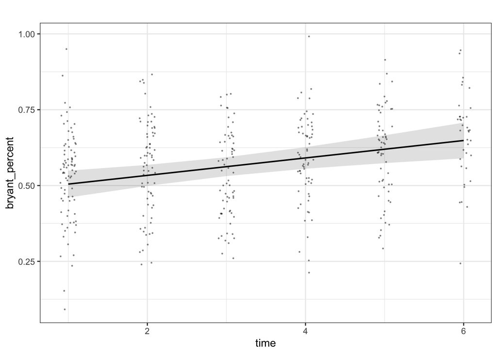

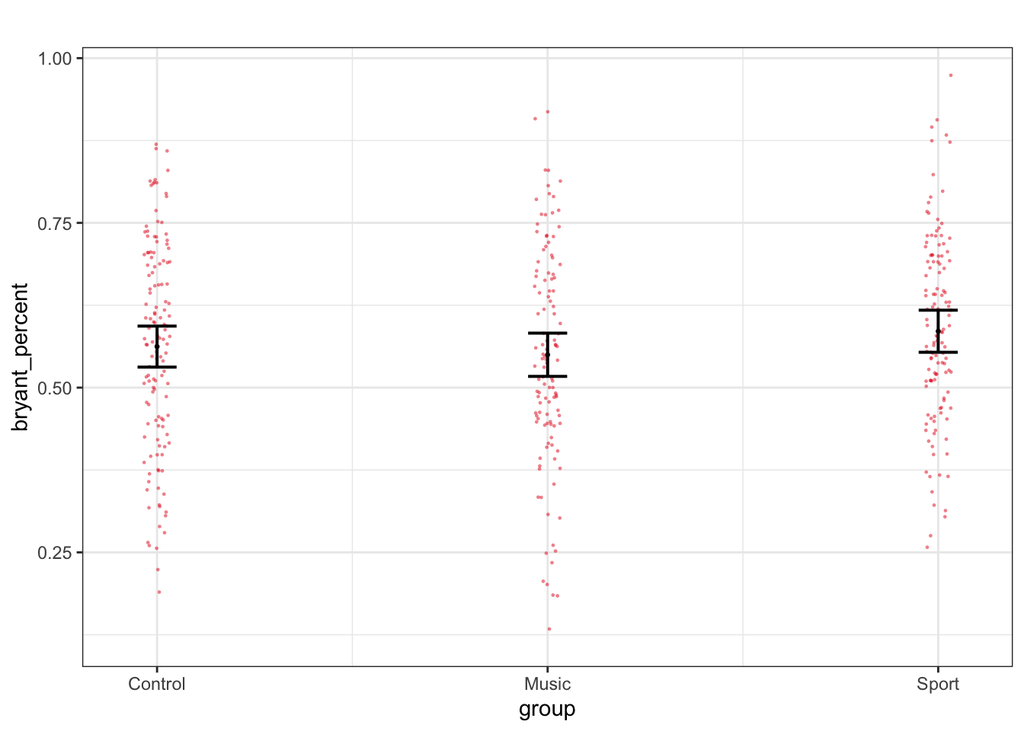

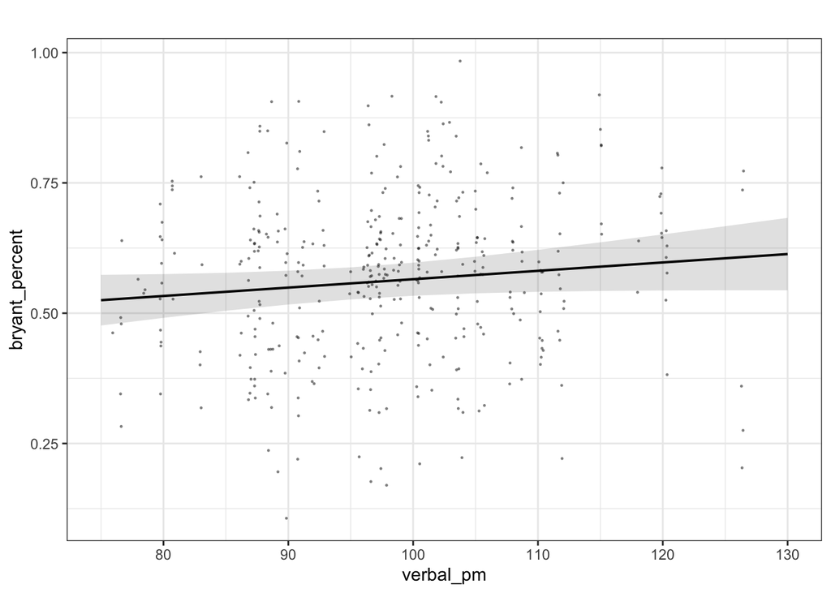

```r
plot_model(m4.1,
    type = "pred", show.data = TRUE,
    title = "", dot.size = 0.5,
    jitter = 0.1
)
```

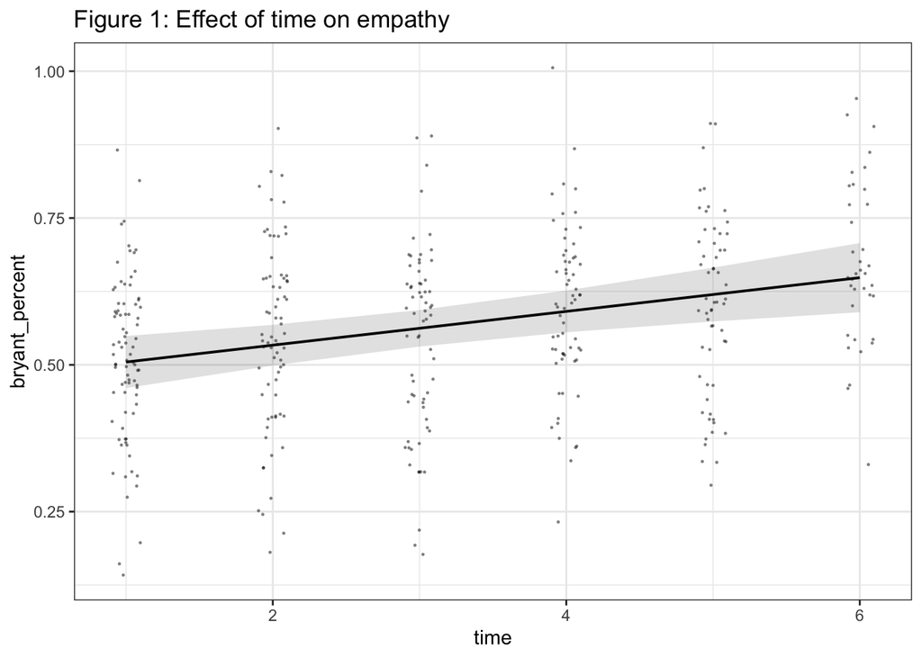

```r
plot_model(m4.1,
    type = "pred", terms = "time",
    show.data = TRUE, jitter = 0.1,
    title = "Figure 1: Effect of time on empathy ",
    dot.size = 0.5
)
```

[figure not shown]

```r
# Interaction plot (year:group)
interact_plot(m4.1,
              pred = "time",
              modx = "group",
              plot.points = TRUE,
              point.size = 0.5,
              point.alpha = 0.2,
              jitter = 0.02,
              x.label = "Year",
              y.label = "Bryant Empathy")
```

Summary: The results show a predicted significant increase in the Bryant Index of 0.029 per year, regardless of group, when holding constant participants’ mean verbal IQ and the interaction between time and group (95% CI [0.012, 0.045]; random slope SD = 0.028). Every unit increase in participants’ mean verbal IQ predicted an increase in the Bryant Index of 0.002, when holding constant time, group and the interaction between time and group (95% CI [-0.000, 0.003]). There was no significant effect of group (Music estimate = 0.025, 95% CI [-0.058, 0.109]; Sport estimate = 0.038, 95% CI [-0.043, 0.120]) and no significant interaction between group and time (Time × Music estimate = -0.013, 95% CI [-0.036, 0.011]; Time × Sport estimate = -0.005, 95% CI [-0.028, 0.018]) on the Bryant Index, when holding constant the other variables.